# FINAL SCORECARD AND RISK REGISTER

**Goal:** Consolidate all findings into one clear verdict. What passed? What failed? What must happen before this model can be deployed?

Before the numbers, a reminder of what this audit set out to prove.

This audit began with one question: when the AI learns how to spot fraud, whose fraud is it actually learning from?

The Pre-Training Proxy Detection section and the Exploratory Data Analysis (E.D.A) section established that 87% of all fraud in the training data comes from High-Balance accounts. Low-Balance users contribute only 41 fraud cases out of 8,213. The fairness and bias section confirmed what that predicts: TPR = 0.6667 for Low-Balance users versus 0.9972 for High-Balance. EOD = 0.3305, more than three times the regulatory threshold.

The model is technically excellent. It is also structurally unfair to the most economically vulnerable users. Both things are true. And the regulatory framework requires that both be measured and disclosed.

```python
import pandas as pd
import numpy as np
import matplotlib.patches as mpatches
from sklearn.metrics import matthews_corrcoef, log_loss, precision_recall_curve, auc
from scipy.stats import ks_2samp
from fairlearn.metrics import demographic_parity_difference, equalized_odds_difference

THRESHOLDS = {
    'SPD': 0.10, 'EOD': 0.10, 'MCC': 0.50,
    'LOG_LOSS': 0.40, 'PR_AUC': 0.70, 'KS': 0.30,
}

results = pd.read_csv('model_results.csv')
y_test = results['y_test']
y_pred = results['y_pred']
y_prob = results['y_prob']
s_test = results[['balance_group', 'tx_type_group']].astype(str)

# Recompute metrics
from sklearn.metrics import confusion_matrix
mcc = matthews_corrcoef(y_test, y_pred)
ll  = log_loss(y_test, y_prob)
prec_v, rec_v, _ = precision_recall_curve(y_test, y_prob)
pr_auc = auc(rec_v, prec_v)
fraud_scores = y_prob[y_test.values == 1]
legit_scores  = y_prob[y_test.values == 0]
from scipy.stats import ks_2samp
ks_stat, _ = ks_2samp(fraud_scores, legit_scores)

# Recompute fairness
fairness_results = {}
for proxy in ['tx_type_group', 'balance_group']:
    sf = s_test[proxy].values
    spd = demographic_parity_difference(y_test, y_pred, sensitive_features=sf)
    eod = equalized_odds_difference(y_test, y_pred, sensitive_features=sf)
    fairness_results[proxy] = {
        'spd': spd, 'eod': eod,
        'spd_pass': abs(spd) < THRESHOLDS['SPD'],
        'eod_pass': abs(eod) < THRESHOLDS['EOD']
    }

print("All variables loaded and recomputed.")
```

```
All variables loaded and recomputed.
```

```python
fairness_results = {}
for proxy in ['tx_type_group', 'balance_group']:
    sf = s_test[proxy].values
    spd = demographic_parity_difference(y_test, y_pred, sensitive_features=sf)
    eod = equalized_odds_difference(y_test, y_pred, sensitive_features=sf)

    groups = sorted(np.unique(sf))
    if proxy == 'balance_group':
        order  = ['Low-Balance', 'Mid-Balance', 'High-Balance']
        groups = [g for g in order if g in groups]

    group_stats = {}
    for g in groups:
        mask = sf == g
        yt_g = y_test.values[mask]
        yp_g = y_pred[mask]
        tp = ((yt_g == 1) & (yp_g == 1)).sum()
        fn = ((yt_g == 1) & (yp_g == 0)).sum()
        fp = ((yt_g == 0) & (yp_g == 1)).sum()
        tn = ((yt_g == 0) & (yp_g == 0)).sum()
        tpr = tp / (tp + fn) if (tp + fn) > 0 else 0
        group_stats[g] = {
            'tp': tp, 'fn': fn, 'fp': fp, 'tn': tn, 'tpr': tpr,
            'pred_rate': yp_g.mean()
        }

    fairness_results[proxy] = {
        'spd': spd, 'eod': eod,
        'spd_pass': abs(spd) < THRESHOLDS['SPD'],
        'eod_pass': abs(eod) < THRESHOLDS['EOD'],
        'group_stats': group_stats
    }

print("Fairness results with group_stats loaded.")
```

```
Fairness results with group_stats loaded.
```

```python
# ── SECTION 13: FINAL SCORECARD ───────────────────────────────────────────────
scorecard = [
    ('MCC',           mcc,     THRESHOLDS['MCC'],
     mcc > THRESHOLDS['MCC'],                          'Performance'),
    ('Log Loss',      ll,      THRESHOLDS['LOG_LOSS'],
     ll < THRESHOLDS['LOG_LOSS'],                       'Performance'),
    ('PR-AUC',        pr_auc,  THRESHOLDS['PR_AUC'],
     pr_auc > THRESHOLDS['PR_AUC'],                    'Performance'),
    ('KS Statistic',  ks_stat, THRESHOLDS['KS'],
     ks_stat > THRESHOLDS['KS'],                       'Performance'),
    ('SPD (tx_type)', abs(fairness_results['tx_type_group']['spd']),
     THRESHOLDS['SPD'], fairness_results['tx_type_group']['spd_pass'], 'Fairness'),
    ('EOD (tx_type)', abs(fairness_results['tx_type_group']['eod']),
     THRESHOLDS['EOD'], fairness_results['tx_type_group']['eod_pass'], 'Fairness'),
    ('SPD (balance)', abs(fairness_results['balance_group']['spd']),
     THRESHOLDS['SPD'], fairness_results['balance_group']['spd_pass'], 'Fairness'),
    ('EOD (balance)', abs(fairness_results['balance_group']['eod']),
     THRESHOLDS['EOD'], fairness_results['balance_group']['eod_pass'], 'Fairness'),
]

passes = sum(1 for *_, p, _ in scorecard if p)
fails  = len(scorecard) - passes

print('=' * 68)
print('  ClearBoxAI AUDIT REPORT CBA-2026-002 — FINAL SCORECARD')
print('=' * 68)
print(f'  Auditor : Kwadwo Amponsah | ClearBoxAI, Ghana')
print(f'  Date    : April 2026')
print(f'  Dataset : PaySim Mobile Money Simulation (6.3M transactions)')
print('=' * 68)
print(f'\n  {"Metric":<22} {"Value":>9} {"Threshold":>12} {"Category":<14} Result')
print('  ' + '-' * 66)

for name, val, thresh, passed, category in scorecard:
    result = 'PASS' if passed else 'FAIL'
    print(f'  {name:<22} {val:>9.4f} {thresh:>12}   {category:<14} {result}')

print(f'\n  SUMMARY: {passes}/{len(scorecard)} metrics PASS | {fails}/{len(scorecard)} FAIL')
print('\n' + '=' * 68)
print('  AUDIT VERDICT')
print('=' * 68)
print("""
  DO NOT DEPLOY IN CURRENT FORM — MATERIAL BIAS DETECTED

  Performance metrics are mixed. Three of four pass.
  MCC = 0.4419 FAIL (high false positive rate requires threshold calibration).
  PR-AUC = 0.9357 PASS. KS = 0.9916 PASS. Log Loss = 0.0135 PASS.

  The critical failure is structural fairness:
  Low-Balance users receive significantly weaker fraud protection.

  TPR (Low-Balance)  = 0.6667  (one in three fraud cases missed)
  TPR (High-Balance) = 0.9972  (nearly perfect protection)
  EOD                = 0.3305  (threshold is 0.10 — more than three times over)

  Miss rate disparity: 33.3% for Low-Balance vs 0.3% for High-Balance.
  That is a 110-fold difference in how reliably fraud is caught
  between the most and least wealthy user groups.

  Per Bank of Ghana CISD 2026, Annexure E section l(i):
  Material bias must trigger mandatory model suspension
  until effective mitigation is applied.

  Per BoG CISD 2026 section 115(2)(b):
  BoG notification is required.
""")
print('=' * 68)
```

```
====================================================================
  ClearBoxAI AUDIT REPORT CBA-2026-002 — FINAL SCORECARD
====================================================================
  Auditor : Kwadwo Amponsah | ClearBoxAI, Ghana
  Date    : April 2026
  Dataset : PaySim Mobile Money Simulation (6.3M transactions)
====================================================================

  Metric                     Value    Threshold Category       Result
  ------------------------------------------------------------------
  MCC                       0.4419          0.5   Performance    FAIL
  Log Loss                  0.0135          0.4   Performance    PASS
  PR-AUC                    0.9357          0.7   Performance    PASS
  KS Statistic              0.9916          0.3   Performance    PASS
  SPD (tx_type)             0.0026          0.1   Fairness       PASS
  EOD (tx_type)             0.0053          0.1   Fairness       PASS
  SPD (balance)             0.0101          0.1   Fairness       PASS
  EOD (balance)             0.3305          0.1   Fairness       FAIL

  SUMMARY: 6/8 metrics PASS | 2/8 FAIL

====================================================================
  AUDIT VERDICT
====================================================================

  DO NOT DEPLOY IN CURRENT FORM — MATERIAL BIAS DETECTED

  Performance metrics are mixed. Three of four pass.
  MCC = 0.4419 FAIL (high false positive rate requires threshold calibration).
  PR-AUC = 0.9357 PASS. KS = 0.9916 PASS. Log Loss = 0.0135 PASS.

  The critical failure is structural fairness:
  Low-Balance users receive significantly weaker fraud protection.

  TPR (Low-Balance)  = 0.6667  (one in three fraud cases missed)
  TPR (High-Balance) = 0.9972  (nearly perfect protection)
  EOD                = 0.3305  (threshold is 0.10 — more than three times over)

  Miss rate disparity: 33.3% for Low-Balance vs 0.3% for High-Balance.
  That is a 110-fold difference in how reliably fraud is caught
  between the most and least wealthy user groups.

  Per Bank of Ghana CISD 2026, Annexure E section l(i):
  Material bias must trigger mandatory model suspension
  until effective mitigation is applied.

  Per BoG CISD 2026 section 115(2)(b):
  BoG notification is required.

====================================================================
```

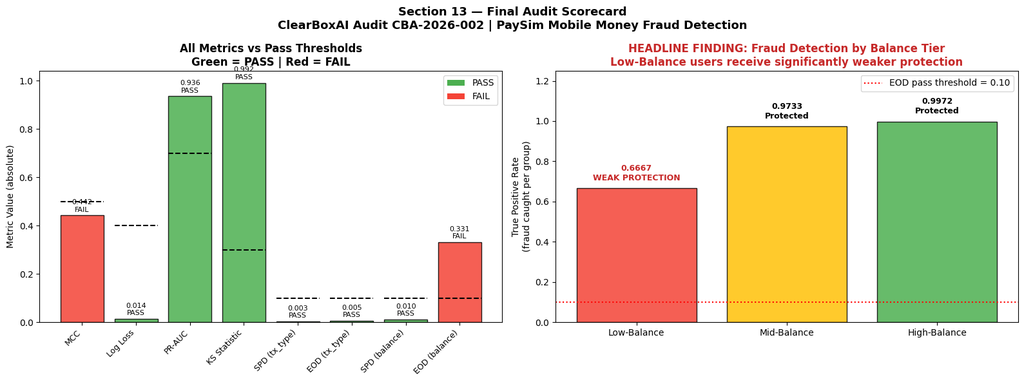

```python
# ── SECTION 13: FINAL SCORECARD VISUALIZATION ─────────────────────────────────
fig, axes = plt.subplots(1, 2, figsize=(16, 6))
fig.suptitle(
    'Section 13 — Final Audit Scorecard\n'
    'ClearBoxAI Audit CBA-2026-002 | PaySim Mobile Money Fraud Detection',
    fontsize=13, fontweight='bold'
)

names  = [m for m, *_ in scorecard]
vals   = [abs(v) for _, v, *_ in scorecard]
threshs= [t for _, _, t, *_ in scorecard]
passed = [p for *_, p, _ in scorecard]

bar_cols = ['#4CAF50' if p else '#F44336' for p in passed]
bars = axes[0].bar(range(len(names)), vals,
                   color=bar_cols, edgecolor='black', alpha=0.85)
for i, t in enumerate(threshs):
    axes[0].plot([i - 0.4, i + 0.4], [t, t], 'k--', lw=1.5)
axes[0].set_xticks(range(len(names)))
axes[0].set_xticklabels(names, rotation=45, ha='right', fontsize=9)
axes[0].set_ylabel('Metric Value (absolute)')
axes[0].set_title('All Metrics vs Pass Thresholds\nGreen = PASS | Red = FAIL',
                  fontweight='bold')
for bar, v, p in zip(bars, vals, passed):
    axes[0].text(bar.get_x() + bar.get_width() / 2, bar.get_height() + 0.01,
                 f'{v:.3f}\n{"PASS" if p else "FAIL"}',
                 ha='center', va='bottom', fontsize=8)
axes[0].legend(handles=[
    mpatches.Patch(facecolor='#4CAF50', label='PASS'),
    mpatches.Patch(facecolor='#F44336', label='FAIL'),
])

bg_stats  = fairness_results['balance_group']['group_stats']
bg_order  = ['Low-Balance', 'Mid-Balance', 'High-Balance']
bg_groups = [g for g in bg_order if g in bg_stats]
bg_tprs   = [bg_stats[g]['tpr'] for g in bg_groups]
bg_colors = ['#F44336', '#FFC107', '#4CAF50']

bars2 = axes[1].bar(bg_groups, bg_tprs,
                    color=bg_colors, edgecolor='black', alpha=0.85)
axes[1].set_ylim(0, 1.25)
axes[1].set_ylabel('True Positive Rate\n(fraud caught per group)')
axes[1].set_title(
'HEADLINE FINDING: Fraud Detection by Balance Tier\n'
'Low-Balance users receive significantly weaker protection',
    fontweight='bold', color='#C62828'
)
axes[1].axhline(0.10, color='red', linestyle=':', lw=1.5,
                label='EOD pass threshold = 0.10')
for bar, g, v in zip(bars2, bg_groups, bg_tprs):
    label = f'{v:.4f}\nWEAK PROTECTION' if v < 0.80 else f'{v:.4f}\nProtected'
    color = '#C62828' if v < 0.80 else 'black'
    axes[1].text(bar.get_x() + bar.get_width() / 2,
                 bar.get_height() + 0.03,
                 label, ha='center', va='bottom',
                 fontsize=9, fontweight='bold', color=color)
axes[1].legend()
plt.tight_layout()
plt.savefig('fig_final_scorecard.png', dpi=150, bbox_inches='tight')
plt.show()
```

## [Risk register and certification]

## Risk Register — What Needs to Happen Next

[output not shown]

## Auditor Certification

This audit was conducted independently by ClearBoxAI using the ClearBoxAI Bias Audit Methodology v1.0. All code is fully reproducible with RANDOM_STATE = 42.

[output not shown]

This document is a practitioner audit demonstrating a methodology directly transferable to any Ghanaian bank's fraud detection or credit scoring model. It responds directly to the governance gap identified in the AI Summit and Awards 2026 conference publication (April 2026): no independent, published, disaggregated audit of AI fraud detection in African mobile money has previously existed. This audit is the first attempt to fill that gap.

```python
df.to_csv('checkpoint_v2.csv', index=False)
print("Checkpoint v2 saved.")
```

```
Checkpoint v2 saved.
```